# Assignment LAB 4 Sheet

**DINESH YOGESH PAREKH** **20MCA1013**

## Linear Regression

Q1. Consider the following sample dataset and write a program to project it in the form of a scatter plot and observe any relationship that exists in between the experience and pay.

```python
import numpy as np
import pandas as pd
```

```python
X = np.array([2, 3, 5, 13, 8, 16, 11, 1, 9, 4])     #Experience (In Years)
y = np.array([15, 28, 42, 64, 50, 90, 58, 8, 54, 30])   #Pay (In 1000 Rs.)
print(X)
print(y)
# Create pandas dataframe to store our X and y values
df = pd.DataFrame(
    {'Experience (In Years)': X,
     'Pay (In 1000 Rs.)': y}
)

# Show the first five rows of our dataframe
df.head()
```

```
[ 2  3  5 13  8 16 11  1  9  4]
[15 28 42 64 50 90 58  8 54 30]
```

|  | Experience (In Years) | Pay (In 1000 Rs.) |
| --- | --- | --- |
| 0 | 2 | 15 |
| 1 | 3 | 28 |
| 2 | 5 | 42 |
| 3 | 13 | 64 |
| 4 | 8 | 50 |

```python
df.columns
```

```
Index(['Experience (In Years)', 'Pay (In 1000 Rs.)'], dtype='object')
```

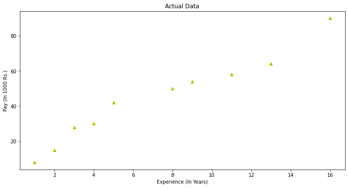

```python
from matplotlib import pyplot as plt
%matplotlib inline
plt.figure(figsize=(12, 6))
plt.plot(X, y, 'y^')   # scatter plot showing actual data
plt.title('Actual Data')
plt.xlabel('Experience (In Years)')
plt.ylabel('Pay (In 1000 Rs.)')
plt.show()
```

```python
# Calculate the mean of X and y
xmean = np.mean(df['Experience (In Years)'])
ymean = np.mean(df['Pay (In 1000 Rs.)'])

# Calculate the terms needed for the numator and denominator of beta
df['xycov'] = (df['Experience (In Years)'] - xmean) * (df['Pay (In 1000 Rs.)'] - ymean)
df['xvar'] = (df['Experience (In Years)'] - xmean)**2

# Calculate beta and alpha
beta = df['xycov'].sum() / df['xvar'].sum()
alpha = ymean - (beta * xmean)
print(f'alpha = {np.round(alpha,2)}')
print(f'beta = {np.round(beta,2)}')
```

```
alpha = 9.51
beta = 4.78
```

```python
df.head()
```

|  | Experience (In Years) | Pay (In 1000 Rs.) | xycov | xvar |
| --- | --- | --- | --- | --- |
| 0 | 2 | 15 | 150.28 | 27.04 |
| 1 | 3 | 28 | 66.78 | 17.64 |
| 2 | 5 | 42 | 4.18 | 4.84 |
| 3 | 13 | 64 | 116.58 | 33.64 |
| 4 | 8 | 50 | 4.88 | 0.64 |

```python
ypred = alpha + beta*X
len(ypred)
```

```
10
```

```python
ypred
```

```
array([19.06063269, 23.83743409, 33.39103691, 71.60544815, 47.72144112,
       85.93585237, 62.05184534, 14.28383128, 52.49824253, 28.6142355 ])
```

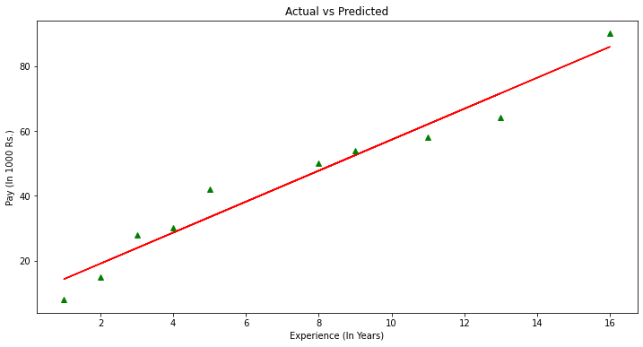

```python
from matplotlib import pyplot as plt
%matplotlib inline
# Plot regression against actual data
plt.figure(figsize=(12, 6))
plt.plot(X, ypred,'RED')     # regression line
plt.plot(X, y, 'g^')   # scatter plot showing actual data
plt.title('Actual vs Predicted')
plt.xlabel('Experience (In Years)')
plt.ylabel('Pay (In 1000 Rs.)')
plt.show()
```

Q2. Fill the following table by using the respective values of 𝒙 and 𝒚

```python
X = np.array([2, 3, 5, 13, 8, 16, 11, 1, 9, 4])     #X column
y = np.array([15, 28, 42, 64, 50, 90, 58, 8, 54, 30])   #y column
# Create pandas dataframe to store our X and y values
df = pd.DataFrame(
    {'X': X,
     'y': y}
)
# Show the first five rows of our dataframe
df.head()
```

|  | X | y |
| --- | --- | --- |
| 0 | 2 | 15 |
| 1 | 3 | 28 |
| 2 | 5 | 42 |
| 3 | 13 | 64 |
| 4 | 8 | 50 |

```python
# Calculate the mean of X and y
xmean = np.mean(df['X'])
ymean = np.mean(df['y'])

df['x-x̅'] = (df['X'] - xmean)
df['y-y̅'] = (df['y'] - ymean)

df['(x-x̅)*(y-y̅)'] =(df['x-x̅']*df['y-y̅'])

df['(x-x̅)^2']= (df['x-x̅']*df['x-x̅'])

x_ybarsum = df['(x-x̅)*(y-y̅)'].sum()
x_barsquaresum = df['(x-x̅)^2'].sum()
print('xmean=',xmean)
print('ymean=',ymean)
print('(x-x̅)*(y-y̅) Sum = ',x_ybarsum)
print('(x-x̅)^2 Sum =',x_barsquaresum)
```

```
xmean= 7.2
ymean= 43.9
(x-x̅)*(y-y̅) Sum =  1087.2
(x-x̅)^2 Sum = 227.60000000000002
```

```python
df.head(10)
```

|  | X | y | x-x̅ | y-y̅ | (x-x̅)*(y-y̅) | (x-x̅)^2 |
| --- | --- | --- | --- | --- | --- | --- |
| 0 | 2 | 15 | -5.2 | -28.9 | 150.28 | 27.04 |
| 1 | 3 | 28 | -4.2 | -15.9 | 66.78 | 17.64 |
| 2 | 5 | 42 | -2.2 | -1.9 | 4.18 | 4.84 |
| 3 | 13 | 64 | 5.8 | 20.1 | 116.58 | 33.64 |
| 4 | 8 | 50 | 0.8 | 6.1 | 4.88 | 0.64 |
| 5 | 16 | 90 | 8.8 | 46.1 | 405.68 | 77.44 |
| 6 | 11 | 58 | 3.8 | 14.1 | 53.58 | 14.44 |
| 7 | 1 | 8 | -6.2 | -35.9 | 222.58 | 38.44 |
| 8 | 9 | 54 | 1.8 | 10.1 | 18.18 | 3.24 |
| 9 | 4 | 30 | -3.2 | -13.9 | 44.48 | 10.24 |

Q3. Use the above table and solve the following equations (using OLS method) for finding the values of 𝑤0 and 𝑤1.

𝑤1 =∑ (𝑥𝑖 − 𝑥̅)(𝑦𝑖 − 𝑦̅) / (𝑥𝑖 − 𝑥̅)^2

𝑤0 = 𝑦̅ − 𝑤1𝑥̅

```python
w1=df['(x-x̅)*(y-y̅)'].sum()/df['(x-x̅)^2'].sum()   #beta

w0=ymean-w1*xmean                           #alpha


print(f'alpha = {np.round(w0,2)}')
print(f'beta = {np.round(w1,2)}')
```

```
alpha = 9.51
beta = 4.78
```

Great, we now have an estimate for alpha and beta! Our model can be written as Yₑ = 9.51 + 4.78X , and we can make predictions:

```python
df.head()
```

|  | X | y | x-x̅ | y-y̅ | (x-x̅)*(y-y̅) | (x-x̅)^2 |
| --- | --- | --- | --- | --- | --- | --- |
| 0 | 2 | 15 | -5.2 | -28.9 | 150.28 | 27.04 |
| 1 | 3 | 28 | -4.2 | -15.9 | 66.78 | 17.64 |
| 2 | 5 | 42 | -2.2 | -1.9 | 4.18 | 4.84 |
| 3 | 13 | 64 | 5.8 | 20.1 | 116.58 | 33.64 |
| 4 | 8 | 50 | 0.8 | 6.1 | 4.88 | 0.64 |

```python
ypred=w0 + w1 * X
```

```python
len(ypred)
```

```
10
```

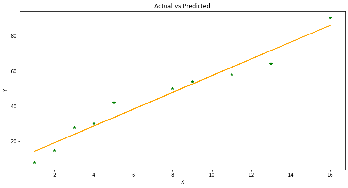

```python
from matplotlib import pyplot as plt
%matplotlib inline
# Plot regression against actual data
plt.figure(figsize=(12, 6))
plt.plot(X, ypred,'ORANGE')     # regression line
plt.plot(X, y, 'g*')   # scatter plot showing actual data
plt.title('Actual vs Predicted')
plt.xlabel('X')
plt.ylabel('Y')
plt.show()
```

Q4. Write a python program to find the above two values (𝑤0 and 𝑤1) for any given dataset.

```python
import numpy as np
import pandas as pd
# Generate 'random' data
np.random.seed(0)            #Even if we rerun the seed method will give us the same random values

X = 2.5 * np.random.randn(100) + 1.5   # Array of 100 values with mean = 1.5, stddev = 2.5
print(type(X))
res = 0.5 * np.random.randn(100)       # Generate 100 residual terms

y = 2 + 0.3 * X + res                  # Actual values of Y

# Create pandas dataframe to store our X and y values
df = pd.DataFrame(
    {'X': X,
     'y': y}
)

# Show the first five rows of our dataframe
df.head()
```

```
<class 'numpy.ndarray'>
```

|  | X | y |
| --- | --- | --- |
| 0 | 5.910131 | 4.714615 |
| 1 | 2.500393 | 2.076238 |
| 2 | 3.946845 | 2.548811 |
| 3 | 7.102233 | 4.615368 |
| 4 | 6.168895 | 3.264107 |

To estimate y using the Ordinary Least Squares regression (OLS) method, we need to calculate xmean and ymean, the covariance of X and y (xycov), and the variance of X (xvar) before we can determine the values for α and β.

```python
# Calculate the mean of X and y
xmean = np.mean(df['X'])
ymean = np.mean(df['y'])

# Calculate the terms needed for the numator and denominator of beta
df['xycov'] = (df['X'] - xmean) * (df['y'] - ymean)
df['xvar'] = (df['X'] - xmean)**2

# Calculate beta and alpha
beta = df['xycov'].sum() / df['xvar'].sum()
alpha = ymean - (beta * xmean)
print(f'alpha = {np.round(alpha,2)}')
print(f'beta = {np.round(beta,2)}')
```

```
alpha = 2.0
beta = 0.32
```

```python
# Alternate Method
from numpy import cov,var
import numpy
covarience=cov(X,y)
var=var(X)
w1=covarience[0][1]/var
w0=y.mean()-(w1*X.mean())
print(f'alpha = {np.round(w0,2)}')
print(f'beta= {np.round(w1,2)}')
```

```
alpha = 2.0
beta= 0.33
```

Our model can be written as **Yₑ = 2.0 + 0.32X** , and we can make predictions

Q5. Write a python program to find the above two values (𝑤0 and 𝑤1) for any given dataset using Normal Equations.

```python
def normalEqn(X,y):                                  # For Reference
    """
    Computes the closed-form solution to linear regression
    """
    theta = np.linalg.inv(X.T.dot(X)).dot(X.T).dot(y)
    return theta
```

```python
np.random.seed(0)
X = np.array(2.5 * np.random.randn(100) + 1.5)
res =0.5 * np.random.randn(100)
y = np.array(2 + 0.3 * X + res)
print(X.shape,y.shape)
m=len(X)
print(m)
one=np.ones((m,1))
#print(one)
one.shape
```

```
(100,) (100,)
100
```

```
(100, 1)
```

```python
x=np.reshape(X,(m,1))
y=np.reshape(y,(m,1))
print(X.shape)
print(y.shape)
```

```
(100,)
(100, 1)
```

```python
D=np.append(one,x,axis=1)
print(D.shape)
```

```
(100, 2)
```

```python
Dt=np.transpose(D)
print(Dt.shape)
```

```
(2, 100)
```

```python
a=(np.linalg.inv(Dt.dot(D))).dot(Dt).dot(y)
print(a.shape)
print(a)
```

```
(2, 1)
[[2.00316701]
 [0.32293969]]
```

```python
w0=a[0][0]
w1=a[1][0]
```

```python
print(f'w0 = {np.round(w0,2)}')
print(f'w1= {np.round(w1,2)}')
```

```
w0 = 2.0
w1= 0.32
```

```python
ypred=w0 + w1 * X
```

```python
len(ypred)
```

```
100
```

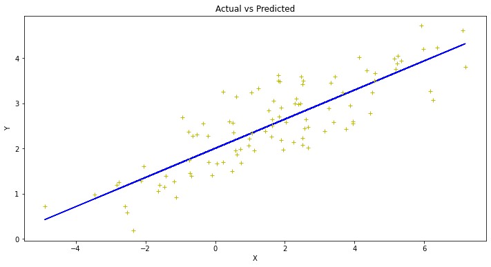

```python
from matplotlib import pyplot as plt
%matplotlib inline
# Plot regression against actual data
plt.figure(figsize=(12, 6))
plt.plot(X, ypred,'blue')     # regression line
plt.plot(X, y, 'y+')   # scatter plot showing actual data
plt.title('Actual vs Predicted')
plt.xlabel('X')
plt.ylabel('Y')
plt.show()
```

Q6. Write a python program to find the above two values (𝑤0 and 𝑤1) for any given dataset using gradient descent.

```
<class 'numpy.ndarray'>
```

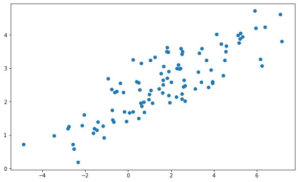

```python
plt.rcParams['figure.figsize'] = (10.0, 6.0)
#data = pd.read_csv('data.csv')


np.random.seed(0)            #Even if we rerun the seed method will give us the same random values
X = 2.5 * np.random.randn(100) + 1.5   # Array of 100 values with mean = 1.5, stddev = 2.5
print(type(X))
res = 0.5 * np.random.randn(100)       # Generate 100 residual terms
Y = 2 + 0.3 * X + res
#X = data.iloc[:, 0]
#Y = data.iloc[:, 1]
plt.scatter(X, Y)
plt.show()
```

```python
w1 = 0
w0 = 0

L = 0.0004          # The learning Rate
epochs = 6000      # The number of iterations to perform gradient descent

n = float(len(X))    # Number of elements in X

# Gradient Descent
for i in range(epochs):
    Y_pred = w1*X + w0                   # The current predicted value of Y
    D_w1 = (-2/n) * sum(X * (Y - Y_pred))  # Derivative wrt w1
    D_w0 = (-2/n) * sum(Y - Y_pred)  # Derivative wrt w0
    w1 = w1 - L * D_w1  # Update w1
    w0 = w0 - L * D_w0  # Update w0

print(w0,w1)
print(f'alpha = {np.round(w0,2)}')
print(f'beta= {np.round(w1,2)}')

Y_pred = w0+w1*X
```

```
1.9303865316443998 0.3372419379978059
alpha = 1.93
beta= 0.34
```

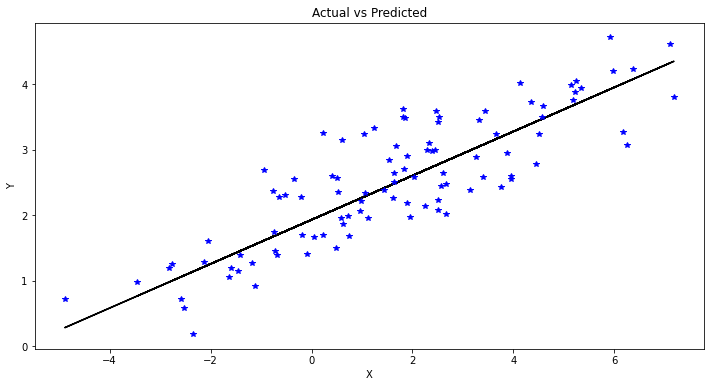

```python
from matplotlib import pyplot as plt
%matplotlib inline
# Plot regression against actual data
plt.figure(figsize=(12, 6))
plt.plot(X, Y_pred,'black')     # regression line
plt.plot(X, Y, 'b*')   # scatter plot showing actual data
plt.title('Actual vs Predicted')
plt.xlabel('X')
plt.ylabel('Y')
plt.show()
```

Q7.Write a python program to store the above dataset as pandas data-frame and implement linear regression model by splitting the dataset into training set and testing set (80:20).

```python
np.random.seed(0)
X = np.array(2.5 * np.random.randn(100) + 1.5)
res =0.5 * np.random.randn(100)
y = np.array(2 + 0.3 * X + res)
```

```python
df=pd.DataFrame({'X':X,'y':Y})
print(df)
X = df.iloc[:, :-1].values
y = df.iloc[:, 1].values
```

```
           X         y
0   5.910131  4.714615
1   2.500393  2.076238
2   3.946845  2.548811
3   7.102233  4.615368
4   6.168895  3.264107
..       ...       ...
95  3.266433  2.894157
96  1.526250  2.843770
97  5.964676  4.201155
98  1.817280  3.626802
99  2.504973  3.419756

[100 rows x 2 columns]
```

```python
from sklearn.model_selection import train_test_split
X_train, X_test, y_train, y_test = train_test_split(X,y, test_size=0.2, random_state=0)
```

```python
len(X_train)
```

```
80
```

```python
len(X_test)
```

```
20
```

```python
len(y_train)
```

```
80
```

```python
len(y_test)
```

```
20
```

#### Fit Regression Model

```python
from sklearn.linear_model import LinearRegression
lin_reg = LinearRegression()
print(lin_reg.fit(X_train,y_train))
```

```
LinearRegression()
```

#### Predict test set values

```python
lin_pred = lin_reg.predict(X_test)
```

#### Model Accuracy

```python
from sklearn.metrics import r2_score, mean_absolute_error,mean_squared_error
print(r2_score(y_test,lin_pred))
print(mean_absolute_error(y_test,lin_pred))
print(mean_squared_error(y_test,lin_pred))### Model Accuracy
```

```
0.6280065468471038
0.41896322254306373
0.245222733362597
```

Q8.. Use the above created linear model on training set and apply on the test set.

```python
lin_reg.fit(X_train, y_train)
lin_pred =lin_reg.predict(X_test)
lin_pred
```

```
array([2.55779645, 3.50691418, 3.33934182, 2.87827342, 1.94580815,
       3.33758355, 3.77103668, 1.48506677, 2.4958572 , 3.11135271,
       1.53046411, 2.69393448, 2.2584814 , 2.62139076, 2.39267504,
       2.64926265, 3.24359262, 4.4208105 , 0.86017638, 2.43299994])
```

Q9.Identify and explain the appropriate metrics for measuring the accuracy of the linear model created above

```python
#r2_score - It is closely related to the Mean squared error.It is used to check how well-observed results are reproduced by the model, depending on the ratio of total deviation of results described by the model
#Mean Absolute Error - MAE is the sum of absolute differences between our target and predicted variables
#Mean Squared Error - It is the Mean of the square of the difference between actual and estimated values.
```

```python
from sklearn.metrics import r2_score, mean_absolute_error,mean_squared_error
print(r2_score(y_test,lin_pred))
print(mean_absolute_error(y_test,lin_pred))
print(mean_squared_error(y_test,lin_pred))### Model Accuracy
```

```
0.6280065468471038
0.41896322254306373
0.245222733362597
```

```python
InterestR=np.array([2.75,2.5,2.5,2.5,2.5,2.5,2.5,2.25,2.25,2.25,2,2,2,1.75,1.75,1.75,1.75,1.75,1.75,1.75,1.75,1.75,1.75,1.75])
UnempR=np.array([5.3,5.3,5.3,5.3,5.4,5.6,5.5,5.5,5.5,5.6,5.7,5.9,6,5.9,5.8,6.1,6.2,6.1,6.1,6.1,5.9,6.2,6.2,6.1])
StockP=np.array([1464,1394,1357,1293,1256,1254,1234,1995,1159,1167,1130,1075,1047,965,943,958,971,949,884,866,876,822,704,719])
```

```python
import pandas as pd
df=pd.DataFrame({
    'Interest_Rate':InterestR,
    'Unemployeement_Rate':UnempR,
    'Stock_Price':StockP
})
df
```

|  | Interest_Rate | Unemployeement_Rate | Stock_Price |
| --- | --- | --- | --- |
| 0 | 2.75 | 5.3 | 1464 |
| 1 | 2.50 | 5.3 | 1394 |
| 2 | 2.50 | 5.3 | 1357 |
| 3 | 2.50 | 5.3 | 1293 |
| 4 | 2.50 | 5.4 | 1256 |
| 5 | 2.50 | 5.6 | 1254 |
| 6 | 2.50 | 5.5 | 1234 |
| 7 | 2.25 | 5.5 | 1995 |
| 8 | 2.25 | 5.5 | 1159 |
| 9 | 2.25 | 5.6 | 1167 |
| 10 | 2.00 | 5.7 | 1130 |
| 11 | 2.00 | 5.9 | 1075 |
| 12 | 2.00 | 6.0 | 1047 |
| 13 | 1.75 | 5.9 | 965 |
| 14 | 1.75 | 5.8 | 943 |
| 15 | 1.75 | 6.1 | 958 |
| 16 | 1.75 | 6.2 | 971 |
| 17 | 1.75 | 6.1 | 949 |
| 18 | 1.75 | 6.1 | 884 |
| 19 | 1.75 | 6.1 | 866 |
| 20 | 1.75 | 5.9 | 876 |
| 21 | 1.75 | 6.2 | 822 |
| 22 | 1.75 | 6.2 | 704 |
| 23 | 1.75 | 6.1 | 719 |

```python
X = df.iloc[:, :-1].values
y = df.iloc[:, 2].values
```

```python
X = np.vstack(X[:, :]).astype(np.float)
X
```

```
array([[2.75, 5.3 ],
       [2.5 , 5.3 ],
       [2.5 , 5.3 ],
       [2.5 , 5.3 ],
       [2.5 , 5.4 ],
       [2.5 , 5.6 ],
       [2.5 , 5.5 ],
       [2.25, 5.5 ],
       [2.25, 5.5 ],
       [2.25, 5.6 ],
       [2.  , 5.7 ],
       [2.  , 5.9 ],
       [2.  , 6.  ],
       [1.75, 5.9 ],
       [1.75, 5.8 ],
       [1.75, 6.1 ],
       [1.75, 6.2 ],
       [1.75, 6.1 ],
       [1.75, 6.1 ],
       [1.75, 6.1 ],
       [1.75, 5.9 ],
       [1.75, 6.2 ],
       [1.75, 6.2 ],
       [1.75, 6.1 ]])
```

```python
y = np.vstack(y[:]).astype(np.float)
y
```

```
array([[1464.],
       [1394.],
       [1357.],
       [1293.],
       [1256.],
       [1254.],
       [1234.],
       [1995.],
       [1159.],
       [1167.],
       [1130.],
       [1075.],
       [1047.],
       [ 965.],
       [ 943.],
       [ 958.],
       [ 971.],
       [ 949.],
       [ 884.],
       [ 866.],
       [ 876.],
       [ 822.],
       [ 704.],
       [ 719.]])
```

```python
df.shape
```

```
(24, 3)
```

```python
y.shape
```

```
(24, 1)
```

### Fit Regression Model

```python
from sklearn.linear_model import LinearRegression
lin_reg = LinearRegression()
print(lin_reg.fit(X_train,y_train))
```

```
LinearRegression()
```

### Predict test set values

```python
lin_pred = lin_reg.predict(X_test)
print(lin_pred)
```

```
[2.55779645 3.50691418 3.33934182 2.87827342 1.94580815 3.33758355
 3.77103668 1.48506677 2.4958572  3.11135271 1.53046411 2.69393448
 2.2584814  2.62139076 2.39267504 2.64926265 3.24359262 4.4208105
 0.86017638 2.43299994]
```

### Model Accuracy

```python
from sklearn.metrics import r2_score, mean_absolute_error,mean_squared_error
print(r2_score(y_test,lin_pred))
print(mean_absolute_error(y_test,lin_pred))
print(mean_squared_error(y_test,lin_pred))
```

```
0.6280065468471038
0.41896322254306373
0.245222733362597
```

```python
df = pd.DataFrame({'Actual': y_test.flatten(), 'Predicted': lin_pred.flatten()})
df
```

[output not shown]